# лекция_3_конспект_фреймворки_метрик

## Фреймворки для продуктовых метрик

Мы познакомились с большим количеством известных метрик, теперь встают важные вопросы - с чего начать и как это все организовать.

Для проектирования метрик существует несколько фреймворков (подходов), которые мы рассмотрим. Они могут помочь, например, если вы запустили продукт и хотите начать отслеживать основные показатели, или у вас уже есть построенные метрики и дашборды, и вы хотите организовать их в понятные структуры, разделить зоны ответсвенности или нарисовать связи между метриками.

### 1. Heart Framework

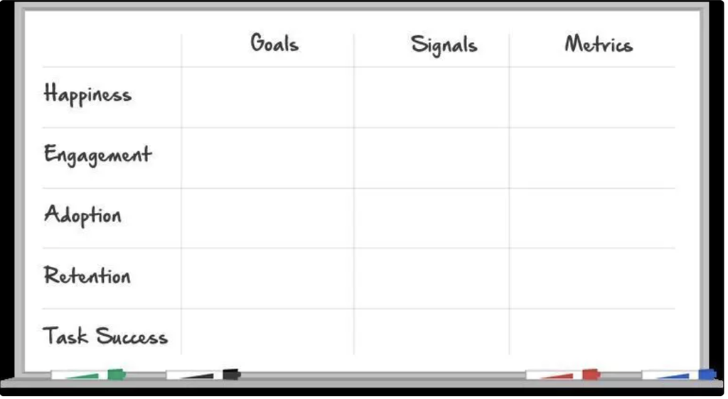

Первый фреймворк который мы рассмотрим - **Heart Framework** от компании Google. Фреймворк разбит на пять категорий: счастье, вовлеченность, принятие, удержание и успех выполнения задачи. Все вместе — это набор ux-метрик, которые позволяют получать обратную связь от пользователей и реагировать на неё в реальном времени.

Для работы с фреймворком Google предлагает систему «цели – сигналы – метрики». Для каждой категории HEART определяют:

**Цель** — что нужно получить; Цели - это общие задачи. В случае категории "Hapiness" целью может быть “Пользователи находят приложение полезным”.

**Сигнал** — что в поведении пользователей укажет на успех или неудачу в достижении цели; Сигналом может быть “Пользователи рекомендуют приложение своим друзьям”.

**Метрику** — количественное измерение сигнала. Измерить то как пользователи рекомендуют приложение своим друзьям, может, например, метрика K-factor, которую мы обсуждали на занятии.

**Пример, как может быть заполнен фреймворк:**

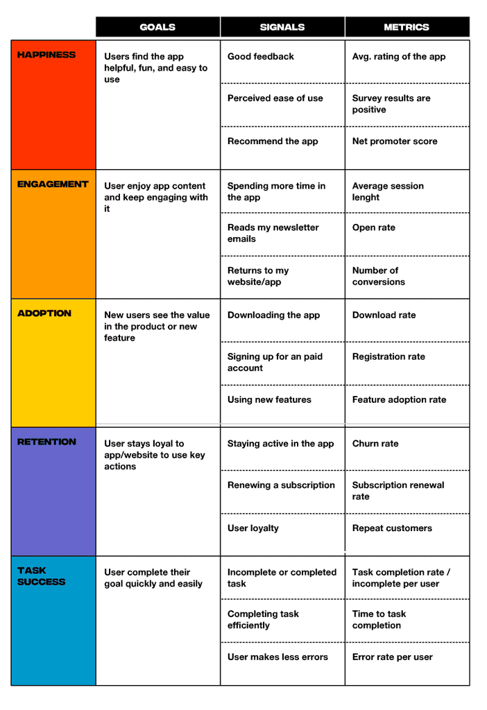

**Комментарий**: На мой взгляд, этот фреймворк не очень подходит для задачи классификации метрик целового продукта. Такие поля как "Happiness" и "Task Success" могут показаться довольно эфемерными, к тому же зачастую в одном продукте существет большое количество фичей, решающих разные задачи. Логировать большое количество решаемых пользовательских задач может быть не очень удобно в таком формате. Как мне кажется, этот фреймворк может быть хорош скорее в рамках проработки конкретной инициативы.

## 2. MixPanel Framework

В продуктовой аналитике существует такое понятие как **North Star Metric**. NSM - это показатель, который лучше всего отражает ценность продукта для пользователя, подробнее можно прочитать тут - https://gopractice.ru/product/the-north-star-metric-guide/

Компания MixPanel предлагает фреймворк для организации работы и раскладывания метрик, который основан на нескольких основных идеях:

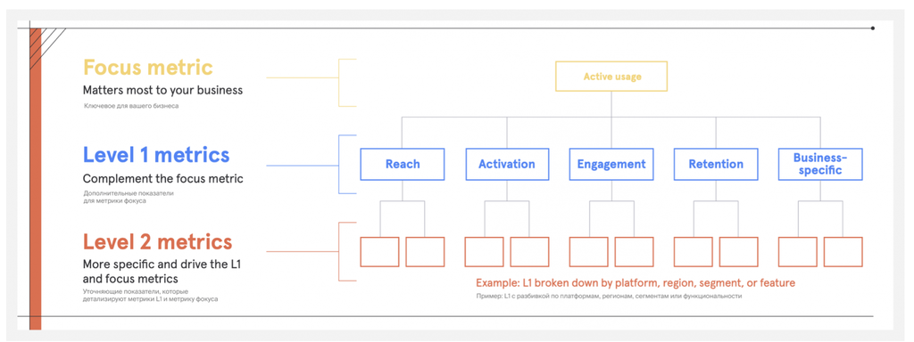

Для более подробного ознакомления, изучите статью и посмотрите на предложенные примеры https://ux-journal.ru/guide-to-product-metrics-mixpanel.html

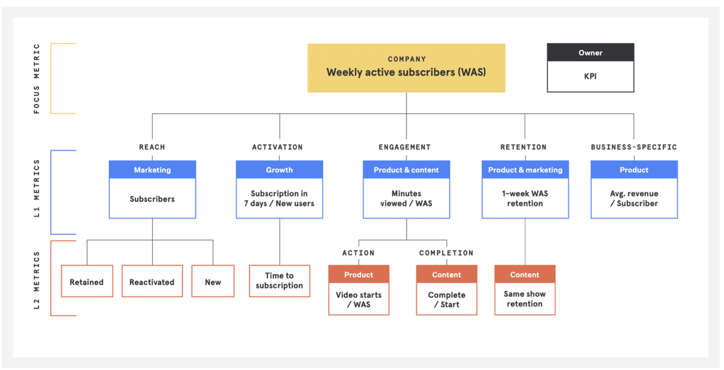

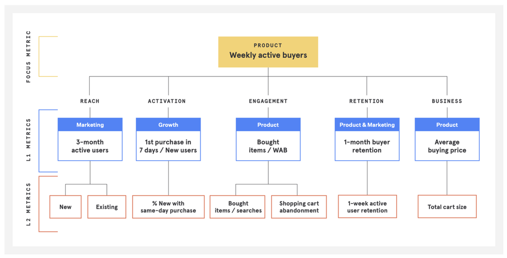

## 3. AARRR Framework

**AARRR Funnel** или пиратская воронка - одна из самых популярных моделей для стартапов и торговых компаний для измерения роста и успеха. Она была представлена Дэйвом Макклюром, основателем Practical Venture Capital, и также называется Pirate Metrics или Пиратский фреймворк. Он разбивает жизненный цикл вашего пользователя на 5 этапов и сопоставляет их с соответствующими показателями – начиная с момента первого контакта и заканчивая моментом, когда потенциальный клиент приносит вам деньги.

Один из распространенных ответов на вопрос «Как растет ваш продукт?» это изображение воронки.

Эти этапы также можно использовать, чтобы разбить ваши метрики по смыслу и по зонам ответсвенности.

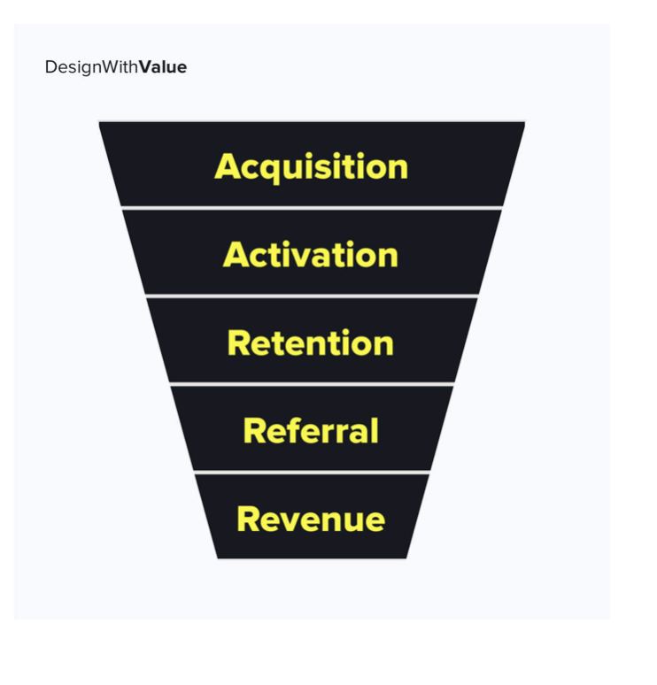

Пример соотношение этапов пользования и метрик

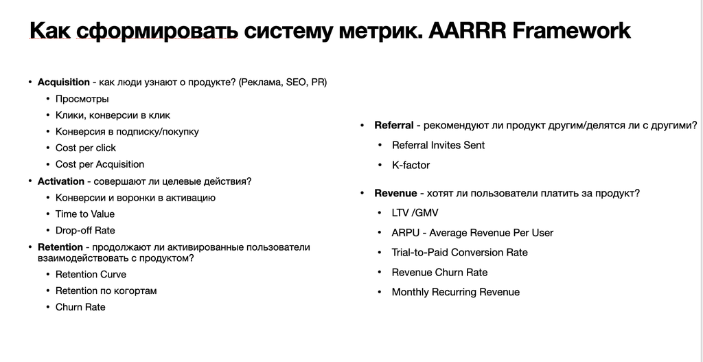

## 4. Свой пример

Приведенные фреймворки существуют не для того, чтобы строго им следовать, а скорее как опора для решения вашей конкретной задачи. Вы можете комбинировать предложенные подходы или добавлять свои. Вот пример как можно верхнеуровнево разложить метрики для продукта видеоконференций, используя подход MixPanel с разбивкой на уровни, но немного поменяв категории на более релевантные

[figure not shown]

## 5. Иерархия метрик

Подходы из пунктов 2, 3, 4 могут помочь вам в организации отчетности и дашбордов и распределении зон ответсвенности между командами, но есть еще один важный инструмент для отображения метрик продукта - это иерархия метрик. Идея иерархии метрик заключается в том, что вы снова выделяете фокусную метрику для продукта/фичи или команды, но теперь расскладываете ее не по смысловым категориям, а именно последовательно разбиваете на ее составляющие. Каждое следующие разбиение - это именно комбинация которая формирует предыдущую метрику.

**Пример для сервиса видеоконференций:**

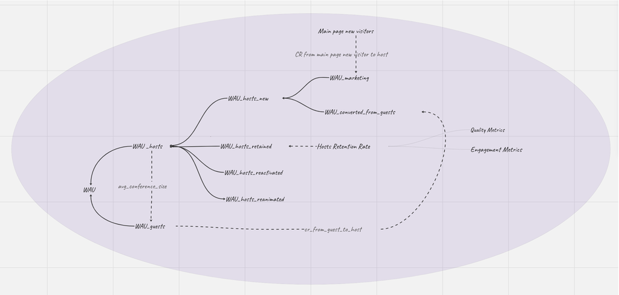

Ваша фокусная метрика - это общий WAU.

- WAU для вас - это количество уникальных пользователей в неделю, которые приняли участие хотя бы в одной конференции. Это WAU можно разделить на создателей (хостов) и участников конференции. Вашим стимулом роста являются именно создатели конференций, поэтому дальше фокусируемся на раскладке WAU хостов.
- WAU хостов состоит из новых пользователей (new), тех что были и на прошлой неделе и на этой (retained), тех что были более недели назад и вернулись на этой неделе (reactivated), и иногда отдельно выделяют тех кто не был уже очень давно и вернулся (например - не был в сервисе три месяца) (reanimated)
- Количество новых хостов в свою очередь можно разложить на каналы привлечения. Создатель конференции может быть привлечен маркетингом. (WAU marketing). Дальше эту метрику можно было бы разложить на маркетинговые каналы (Например те кто пришел из поисковых запросов, тех кто пришел с рекламы и тд, а также конверсии. Например количество хостов привлеченных с рекламы = количество посетителей сайта с рекламы * конверсию посетителей сайта с рекамы в создание конференции. Количество посетителей сайта с рекламы = количество людей увидевших рекламу * конверсию перехода на ваш сайт. И так далее
- Количество удержанных хостов (retained) раскладывается на количество хостов за предыдущий период * Retention Rate
- Retention Rate можно дальше разложить на метрики качества и метрики пользовательского вовлечения или удовлетворенности и так далее

В реальности иерархия может быть очень большой, но это крайне полезный инструмент, который полезно проработать. Она помогает нам определить точки влияния и точки роста, и генерить идеи с помощью чего мы можем влиять на каждую метрику. Также если вы видете рост или падение какой-то метрики визуализация иерархии может вас направить какие причины роста или подения нужно идти проверять.

Такой подход также может помочь на собеседованиях - часто на собесах ПА бывают кейсы по типу "Вам нужно повысить метрику N, что будете делать, какие эксперименты проводить" или "Упала метрика X как будете разбираться"

**Пример иерархии для команды, отвечающей за спрос на маркетплейсе такси (приложени такси)**

Ключевой метрикой для такой команды может быть суммарное количество часов спроса на поездки = Demand Hours. (Тут взяли не количество клиентов делающих заказ или количество заказов, так как заказ для одного клиента может быть выполнен за 10 минут, а может быть за 2 часа. У нас есть емкость водителей в виде человеко-часов которые они могут работать, поэтому и спрос будем оценивать в часах).

- Demand Hours раскладывается на demand hours per user и WAU
- Demand Hours Per User можно разложить на частоту заказов юзера в неделю и среднюю дистанцию заказа
- WAU раскладываем на новых / удержанных с предыдущей недели и реактивированных
- Новых можем разложить на каналы заказа (Первый заказ в приложении / первый заказ на сайте)
- Первый заказ на сайте можем разложить на WAU сайта и конверсию из посещения в заказ
- Удержанных можем разложить на юзеров за прошлую и ретеншн (так как удержанные = юзеры прошлой неделе * ретеншн)
- Реактивированных могли бы дальше разложить на реактивированных органически (вернулись сами) и маркетинговые активности по реактивации (пуши скидки и тд)

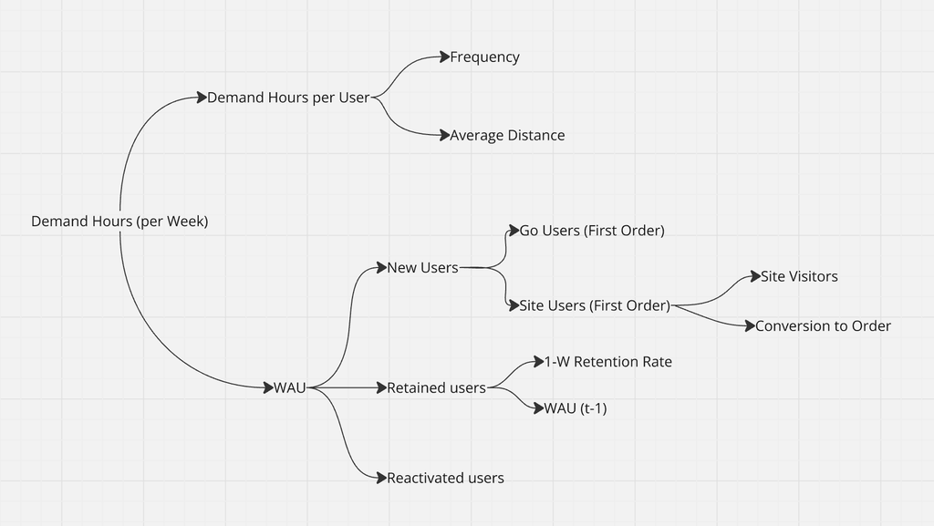